# CM mvpa analysis

This document will contain the figures we publish in our countermeasures manuscript.

# Load packages

First off, we’ll need to **load the packages** we plan to use. This is not so different from setting the matlab path at the beginning of a script.

```r
require(plyr) #plyr is used to summarize data along dimensions we care about
```

```r
require(ggplot2) #ggplot! our favorite plotting tool
require(gridExtra) #gridExtra let's us arrangement figures into grids
require(reshape)
```

# Setup plotting variables

Then, we’ll **setup some plotting environment variables** that we’ll use to control how our plots look.

```r
#the color blind compatible palette we'll use for our colors
cbPalette <- c( "#56B4E9","#009E73", "#F0E442", "#0072B2", "#D55E00", "#CC79A7","#999999", "#E69F00")

#a dashed horizontal line to represent chance for binary classifiers
fiftyline=stat_abline(intercept=.5,slope=0,linetype="dashed",color='black',size=.75,alpha=.9)

#specify font size and face for axis labels and title
plotformat=theme(title= element_text(size=17),axis.title = element_text(size=17),axis.text.x=element_text(size=15),axis.text.y=element_text(size=15), legend.text=element_text(size=20),strip.text.x = element_text(size = 17))+theme_classic()
```

We’ll have to be a little bit clever about getting our color palette into the plots, but the 50% chanceline and plotformats we can just do by adding them to our ggplots, i.e. `myplot + fiftyline`. so simple!

If I wasn’t using this document as an R markdown tutorial, I would probably not show this code chunk in the html output. I could have hidden it by adding `echo=FALSE` to the code chunk header (note: code chunk headers are the thing in the Rmd that looks like : `{r <chunk_title>, echo=TRUE, fig.width = 5}`

# Load the data

Now that we’ve got that setup, we’ll **grab the data** that we plan to use a bunch from our ‘results_sheets’ directory.

```r
dir = "~/cm/Scripts/results_sheets" #all our results csvs live here
#specify the name of each results sheet we'll use
behav_dat_file = sprintf("%s/cm_behav_to_r.csv",dir)
univ_dat_file = sprintf("%s/CM_betas_toR.csv",dir)
mvpa_dat_file = sprintf("%s/aucSummaryToR__exex_excm_cmcm_hitvcr.csv",dir)
#load each results sheet as it's own dataframe
behav_df = read.csv(behav_dat_file, header=T)
univ_df = read.csv(univ_dat_file, header=T)
mvpa_df = read.csv(mvpa_dat_file, header=T)
```

# Behavioral Findings

## Inspect Behavioral Data

The first thing we’ll want to do is have a look at the structure of the behavioral data. We’ll use `head` and `summary` to do this.

```r
head(behav_df) #head shows column headers and the first 6 rows of a data frame
```

```
##   race id overall_d overall_pr   ex_d ex_pr    cm_d cm_pr
## 1   EA  1    1.2183      0.455 1.0558  0.40  1.3893  0.51
## 2   EA  3    1.0908      0.405 1.0870  0.41  1.1054  0.40
## 3   AA  4    0.5718      0.225 0.7169  0.28  0.4297  0.17
## 4   EA  5    0.6770      0.265 0.8543  0.33  0.5082  0.20
## 5   EA  6    0.6933      0.270 1.7697  0.61 -0.1757 -0.07
## 6   EA  7    0.6908      0.270 0.8812  0.34  0.5069  0.20
```

```r
summary(behav_df) #summary provides some information about the distribution of data in the data frame
```

```
##  race          id          overall_d       overall_pr         ex_d
##  AA: 8   Min.   : 1.00   Min.   :0.209   Min.   :0.080   Min.   :0.280
##  EA:16   1st Qu.: 7.75   1st Qu.:0.693   1st Qu.:0.270   1st Qu.:0.849
##          Median :14.50   Median :1.125   Median :0.405   Median :1.207
##          Mean   :14.08   Mean   :1.118   Mean   :0.405   Mean   :1.273
##          3rd Qu.:20.25   3rd Qu.:1.393   3rd Qu.:0.510   3rd Qu.:1.761
##          Max.   :26.00   Max.   :2.138   Max.   :0.715   Max.   :2.307
##      ex_pr            cm_d            cm_pr
##  Min.   :0.110   Min.   :-0.176   Min.   :-0.070
##  1st Qu.:0.323   1st Qu.: 0.508   1st Qu.: 0.200
##  Median :0.450   Median : 1.131   Median : 0.405
##  Mean   :0.450   Mean   : 0.993   Mean   : 0.359
##  3rd Qu.:0.603   3rd Qu.: 1.382   3rd Qu.: 0.502
##  Max.   :0.750   Max.   : 1.991   Max.   : 0.680
```

Great. We can see that this data frame contains overall and task-specific d’ and Pr for 16 EA subjects and 8 AA subjects

For now, we’ll move onto the univariate data. It’ll be happy to see us later.

## Inspect univariate data

```r
summary(univ_df)
```

```
##            Contrast       shape      cluster          sphere
##  CM>EX Hits>CRs:192   cluster:288   Mode :logical   Mode :logical
##  EX>CM Hit>CR  :480   sphere :480   FALSE:480       FALSE:288
##  EX>CM Hits>CRs: 96                 TRUE :288       TRUE :480
##                                     NA's :0         NA's :0
##
##
##          roi      task      acc           beta
##  Left Ang  :192   cm:384   cr :384   Min.   :-6.506
##  Left Hipp :192   ex:384   hit:384   1st Qu.:-0.251
##  Left IPS  : 96                      Median : 0.353
##  Right Hipp:192                      Mean   : 0.435
##  Right IPS : 96                      3rd Qu.: 1.146
##                                      Max.   : 6.550
```

Looks like we have a collection of parameter estimates ($\beta$s) for hits and crs in two tasks (ex and cm) from different contrasts and rois of different shapes (cluster vs sphere).

## Create summary univariate data frame for plotting

A good (but not always necessary) first step to plotting, is to create a summary data frame, with the info you’d like. We’ll do that for the mean and sem of the parameter estimates and we’ll call the result `univ_dfS`.

```r
univ_dfS = ddply(univ_df,.(Contrast, shape, roi, task, acc),summarise,N=length(beta), mean_beta = mean(beta), sd_beta = sd(beta), sem_beta = sd_beta/sqrt(N), min_beta = mean_beta-sem_beta, max_beta = mean_beta+sem_beta)
summary(univ_dfS)
```

```
##            Contrast      shape            roi    task     acc
##  CM>EX Hits>CRs: 8   cluster:12   Left Ang  :8   cm:16   cr :16
##  EX>CM Hit>CR  :20   sphere :20   Left Hipp :8   ex:16   hit:16
##  EX>CM Hits>CRs: 4                Left IPS  :4
##                                   Right Hipp:8
##                                   Right IPS :4
##
##        N        mean_beta         sd_beta         sem_beta
##  Min.   :24   Min.   :-1.440   Min.   :0.464   Min.   :0.0947
##  1st Qu.:24   1st Qu.: 0.008   1st Qu.:0.605   1st Qu.:0.1234
##  Median :24   Median : 0.401   Median :0.981   Median :0.2003
##  Mean   :24   Mean   : 0.434   Mean   :1.051   Mean   :0.2145
##  3rd Qu.:24   3rd Qu.: 0.824   3rd Qu.:1.444   3rd Qu.:0.2948
##  Max.   :24   Max.   : 2.622   Max.   :2.013   Max.   :0.4108
##     min_beta         max_beta
##  Min.   :-1.851   Min.   :-1.029
##  1st Qu.:-0.195   1st Qu.: 0.172
##  Median : 0.302   Median : 0.512
##  Mean   : 0.220   Mean   : 0.649
##  3rd Qu.: 0.674   3rd Qu.: 0.975
##  Max.   : 2.309   Max.   : 2.935
```

The summary looks great! So, now we can plot make some plots using these mean and sem values.

## Make univariate summary plot

Let’s plot our mean $\beta$ for each task and subject accuracy (hit or cr) in facets for each contrast, roi, and sphere vs cluster

First, in order for the plot to display the factors in the order we want, we should reorder them in the data frame.

```r
univ_dfS$task = factor(univ_dfS$task, levels=c("ex","cm"))
univ_dfS$acc = factor(univ_dfS$acc, levels=c("hit","cr"))
```

Ok, now we can write a quick function to plot the data.

```r
plotUnivBetas <- function(pl_df){
#setup a plot h showing mean betas by task and memory
h<-ggplot(pl_df, aes(x=interaction(acc,task), y=mean_beta,ymin=min_beta,ymax=max_beta, fill = task))+#tells our plot what value to put on the x-axis and y-axis and to group values by task. If we tried to plot now, it would say "no layers in plot" and show nothing
   geom_bar(stat='identity',color='black')+
  geom_errorbar(position=position_dodge(1), width=0, size=1, color='black')+#here's the meat of the plot. this specifies that we want points with error bars, tells it what values to use for the error bars, how big their should be, and that they should be 'dodged' by grouping on the x-axis
  scale_fill_manual(values=cbPalette,name="Task",breaks=c("ex","cm"),labels=c("Explicit","Countermeasures"))+
  labs(x="Memory",y="Parameter estimate")+#here we specify what the labels should be
scale_x_discrete(breaks=c("hit.ex","cr.ex","hit.cm","cr.cm"),labels=c("Hit","CR","Hit","CR"))+
    plotformat + #this just tells our plot that it should have axis labels of a certain size, etc (see "Setup plotting variables" section)
theme(legend.text=element_text(size=14))
return(h)
}
```

Let’s look at a first pass with all of the univariate data

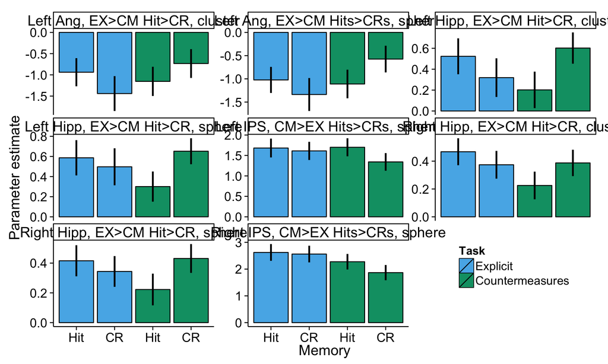

```r
plotUnivBetas(univ_dfS)+  theme(legend.position=c(.85,0.2))+ #let's we move the legend into a postion that's currently vacant
facet_wrap(~roi+Contrast+shape,scales='free_y')#We'll 'facet' by the remaining factors, thereby making a separate plot for each combo of the factors. Note that we have to specify that y axis can be different in each facet. Now, we've got something we can actually think about plotting.
```

## Fig 2. Task x Memory Interaction

Hmmm… we’re actually going to want some more information on ips clusters, so let’s assemble that.

```r
lIps_file = sprintf('%s/lIpsBetas.csv',dir)
lIps_dat = read.csv(lIps_file,header=T)
```

```r
#label roi info
lIps_dat$shape = 'cluster'
lIps_dat$roi = 'Left IPS'
#reshape into data frame
ips_betas = melt(lIps_dat)
```

```r
#label subject numbers
ips_betas$subNo = c(1,3:10,12:26)
#label the task and memory accuracy in the data
ips_betas$task[grepl('Explicit',ips_betas$variable)]='ex'
ips_betas$task[grepl('CM',ips_betas$variable)]='cm'
ips_betas$acc[grepl('Hit',ips_betas$variable)]='hit'
ips_betas$acc[grepl('CR',ips_betas$variable)]='cr'
#reorder factors for plotting
ips_betas$acc = factor(ips_betas$acc,levels=c('hit','cr'))
ips_betas$task = factor(ips_betas$task,levels=c('ex','cm'))
```

```r
#summarize the data, getting the means, etc of beta values and merge with other data frame
#first average across the race variable (not referenced explicitly here)
ips_betas_S = aggregate(value~acc+task+subNo+roi+shape,ips_betas,mean)
ips_betas_S$beta=ips_betas_S$value
#summarize by accuracy, task, roi, shape for use in plot
ips_betas_S=ddply(ips_betas_S,c("acc","task","roi","shape"),summarise,N=length(beta),mean_beta=mean(beta),sd_beta = sd(beta), sem_beta=sd_beta/sqrt(N), min_beta = mean_beta-sem_beta, max_beta = mean_beta+sem_beta)
#merge new data frame with existing data frame
univ_dfS_ms<-merge(univ_dfS,ips_betas_S,all=T)
#choose the subset of the data corresponding to the rois we actually want to put into the plot
univ_dfS_ms<-subset(univ_dfS_ms,roi %in% c("Left Ang", "Left Hipp", "Left IPS"))
univ_dfS_ms$roi = factor(univ_dfS_ms$roi, labels=c("Left AnG", "Left Hippocampus", "Left IPS"))
```

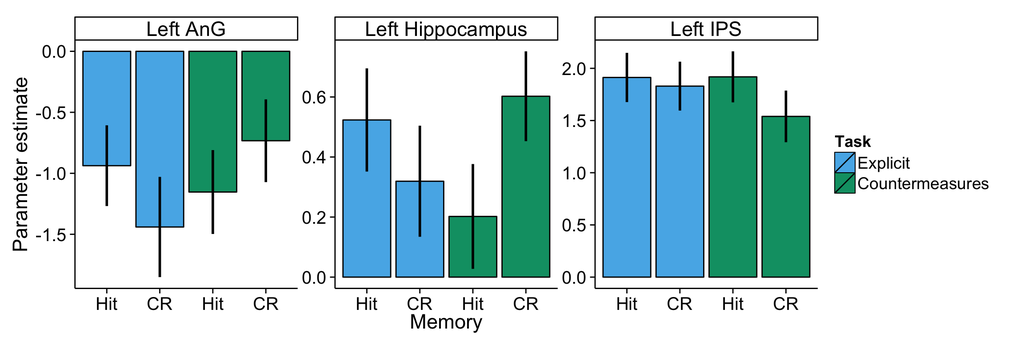

```r
plotUnivBetas(subset(univ_dfS_ms, shape=='cluster'))+facet_wrap(~roi,scales='free_y')
```

## Fig 3. L Ang parameter estimates correlates with CM d’

We also want to know something about how the angular effects correlate with CM d’. Let’s have a look at that.

```r
#first let's grab that cluster
univ_df_ang_sphere = subset(univ_df, shape=='sphere' & roi=="Left Ang" & task=='cm')
#and look at it's structure
summary(univ_df_ang_sphere)
```

```
##            Contrast      shape     cluster         sphere
##  CM>EX Hits>CRs: 0   cluster: 0   Mode :logical   Mode:logical
##  EX>CM Hit>CR  : 0   sphere :48   FALSE:48        TRUE:48
##  EX>CM Hits>CRs:48                NA's :0         NA's:0
##
##
##
##          roi     task     acc          beta
##  Left Ang  :48   cm:48   cr :24   Min.   :-4.314
##  Left Hipp : 0   ex: 0   hit:24   1st Qu.:-1.750
##  Left IPS  : 0                    Median :-0.859
##  Right Hipp: 0                    Mean   :-0.843
##  Right IPS : 0                    3rd Qu.:-0.210
##                                   Max.   : 3.105
```

```r
ang_sphere_cm_memsuccess = univ_df_ang_sphere$beta[univ_df_ang_sphere$acc=='hit']-univ_df_ang_sphere$beta[univ_df_ang_sphere$acc=='cr']
cor.test(ang_sphere_cm_memsuccess,behav_df$cm_d)
```

```
##
##  Pearson's product-moment correlation
##
## data:  ang_sphere_cm_memsuccess and behav_df$cm_d
## t = 0.6582, df = 22, p-value = 0.5173
## alternative hypothesis: true correlation is not equal to 0
## 95 percent confidence interval:
##  -0.2801  0.5136
## sample estimates:
##   cor
## 0.139
```

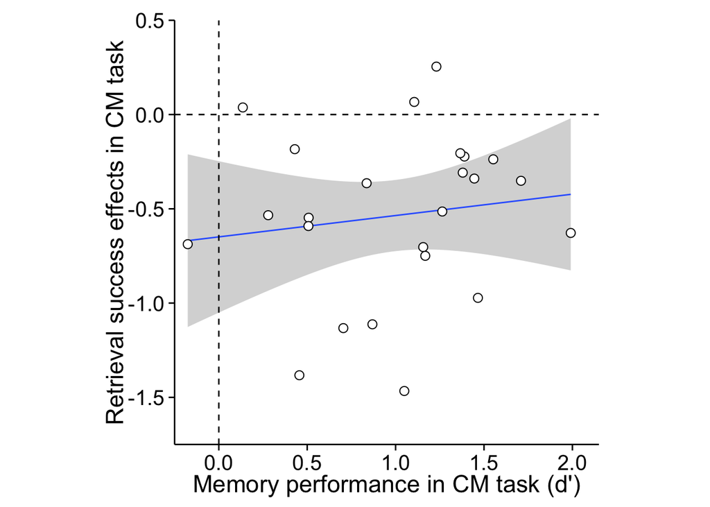

```r
h<-qplot(behav_df$cm_d,ang_sphere_cm_memsuccess,geom='smooth',method='lm')+geom_point(size=3, fill='white',shape=21)+labs(x="Memory performance in CM task (d')",y="Retrieval success effects in CM task")+plotformat+geom_abline(intercept=0,slope=0,linetype='dashed')+geom_vline(x=0,linetype='dashed')

h+coord_equal(ratio=2.4/2.25,xlim=c(-.25,2.15),ylim=c(-1.75,.5))
```

```r
#first let's grab that cluster
univ_df_ang_clus = subset(univ_df, shape=='cluster' & roi=="Left Ang" & task=='cm')
#and look at it's structure
summary(univ_df_ang_clus)
```

```
##            Contrast      shape    cluster          sphere
##  CM>EX Hits>CRs: 0   cluster:48   Mode:logical   Mode :logical
##  EX>CM Hit>CR  :48   sphere : 0   TRUE:48        FALSE:48
##  EX>CM Hits>CRs: 0                NA's:0         NA's :0
##
##
##
##          roi     task     acc          beta
##  Left Ang  :48   cm:48   cr :24   Min.   :-5.193
##  Left Hipp : 0   ex: 0   hit:24   1st Qu.:-1.813
##  Left IPS  : 0                    Median :-0.886
##  Right Hipp: 0                    Mean   :-0.943
##  Right IPS : 0                    3rd Qu.: 0.038
##                                   Max.   : 3.259
```

```r
ang_clus_cm_memsuccess = univ_df_ang_clus$beta[univ_df_ang_clus$acc=='hit']-univ_df_ang_clus$beta[univ_df_ang_clus$acc=='cr']
cor.test(ang_clus_cm_memsuccess,behav_df$cm_d)
```

```
##
##  Pearson's product-moment correlation
##
## data:  ang_clus_cm_memsuccess and behav_df$cm_d
## t = 1.781, df = 22, p-value = 0.08867
## alternative hypothesis: true correlation is not equal to 0
## 95 percent confidence interval:
##  -0.05644  0.66342
## sample estimates:
##   cor
## 0.355
```

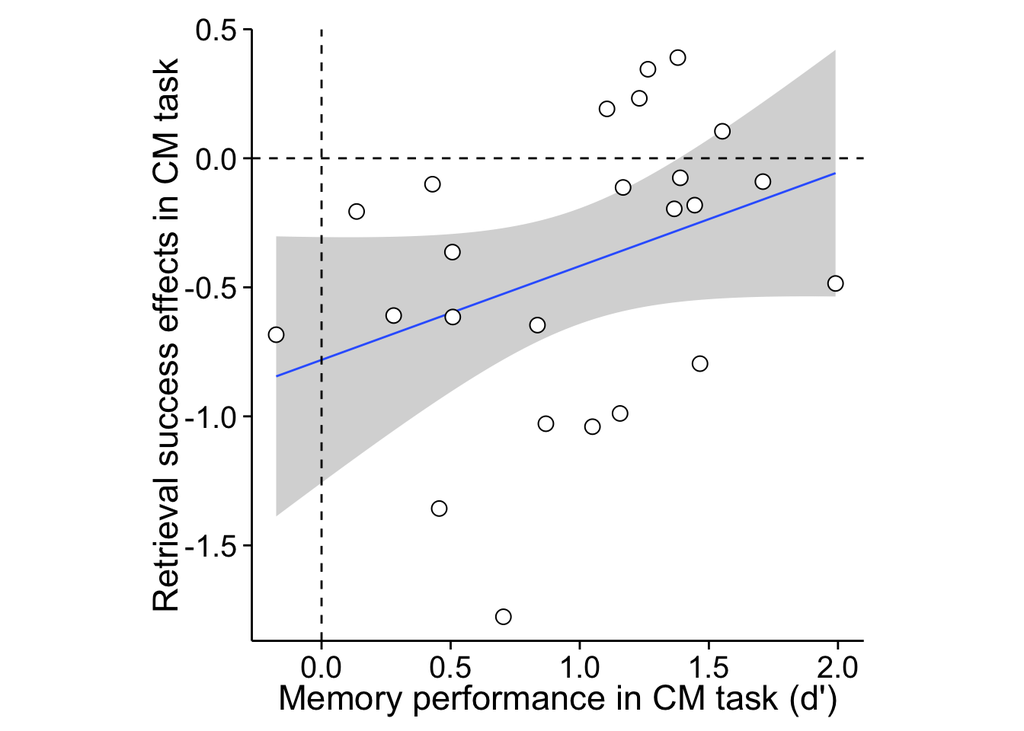

```r
qplot(behav_df$cm_d,ang_clus_cm_memsuccess,geom='smooth',method='lm')+geom_point(size=3.5, fill='white',shape=21)+labs(x="Memory performance in CM task (d')",y="Retrieval success effects in CM task")+plotformat+geom_abline(intercept=0,slope=0,linetype='dashed')+geom_vline(x=0,linetype='dashed')+coord_equal(xlim=c(-.27,2.1),ylim=c(-1.87,.5))
```

# MVPA Findings

## Inspect mvpa data frame

```r
summary(mvpa_df)
```

```
##     train_test       mask          conds        tr     xval_it
##  CM,4fold:168   SEPT...:672   hit v cr:672   1   :96     : 24
##  CM>EX   :168                                2   :96   []:312
##  EX,4fold:168                                3   :96   1 :168
##  EX>CM   :168                                4   :96   2 :168
##                                              5   :96
##                                              6   :96
##                                              late:96
##                                                                                        name
##  conds_hitVcr_trTe1_1_1_1_2_2_2_2_trW0__0__0__0__0__1_roiSEPT09_MVPA_MASK_resliced4mm.mat: 48
##  conds_hitVcr_trTe1_1_1_1_2_2_2_2_trW0__0__0__0__1__0_roiSEPT09_MVPA_MASK_resliced4mm.mat: 48
##  conds_hitVcr_trTe1_1_1_1_2_2_2_2_trW0__0__0__1__0__0_roiSEPT09_MVPA_MASK_resliced4mm.mat: 48
##  conds_hitVcr_trTe1_1_1_1_2_2_2_2_trW0__0__1__0__0__0_roiSEPT09_MVPA_MASK_resliced4mm.mat: 48
##  conds_hitVcr_trTe1_1_1_1_2_2_2_2_trW0__1__0__0__0__0_roiSEPT09_MVPA_MASK_resliced4mm.mat: 48
##  conds_hitVcr_trTe1_1_1_1_2_2_2_2_trW1__0__0__0__0__0_roiSEPT09_MVPA_MASK_resliced4mm.mat: 48
##  (Other)                                                                                 :384
##       sub           auc
##  s01    : 28   Min.   :0.324
##  s03    : 28   1st Qu.:0.489
##  s04    : 28   Median :0.553
##  s05    : 28   Mean   :0.578
##  s06    : 28   3rd Qu.:0.644
##  s07    : 28   Max.   :0.976
##  (Other):504
```

Looks good. It’ll be helpful to have a summary of this, so let’s go ahead and make another dataframe (`mvpa_dfS`) that summarizes the information with mean, sem, and other info.

```r
#reorder factors as appropriate
train_test_levels = c('EX,4fold','CM,4fold','EX>CM','CM>EX')
latetrs_mvpa_df = subset(mvpa_df,tr=='late' & train_test %in% train_test_levels)
latetrs_mvpa_df$train_test=factor(latetrs_mvpa_df$train_test,levels=train_test_levels)
#create summary df
mvpa_dfS<-ddply(mvpa_df,c("mask","conds","tr","name","train_test"),summarise,N=length(auc),mean_auc=mean(auc),sd_auc = sd(auc), sem_auc=sd_auc/sqrt(N), min_auc = mean_auc-sem_auc, max_auc = mean_auc+sem_auc)
```

The first thing we’ll want to plot, is the ex>ex and ex>cm violins and tr by tr stuff that go into figure 4.

First thing I’ll do is write some functions that make these plots easy to create. ####Plotting function for mvpa violins

```r
plotMvpaViolin <- function(pl_df){
  h<-ggplot(pl_df, aes(x=train_test, y=auc))+
    geom_violin(aes(fill=train_test),trim=F,alpha=.6)+
    geom_point(aes(color=sub),show_guide=F)+
    geom_line(aes(color=sub, group=sub),show_guide=F,linetype='dotted')+

    fiftyline+
    theme(axis.ticks=element_blank(),axis.text.x=element_blank())+
    plotformat+
    geom_point(stat='summary',fun.y='mean')
  return(h)
}
```

#### Plotting function for mvpa at each tr

```r
plotMvpaTrRibbons <- function(pl_df){
  h<-ggplot(pl_df, aes(x=trSec,y=mean_auc,ymin=min_auc,ymax=max_auc, group=train_test, fill=train_test, color=train_test)) +
     geom_ribbon(alpha=.65) +
    geom_line(linetype="longdash", size =1)+
    fiftyline+geom_vline(xintercept=0, linetype="dotted")+
    theme_bw() +
    plotformat+
    scale_x_discrete(breaks=seq(2,12,2))
  return(h)
}
```

#### function to fix tr info in mvpa dfs

```r
fixTrInMvpaDf<-function(df){
trCodes = c("1;0;0;0;0;0","0;1;0;0;0;0","0;0;1;0;0;0","0;0;0;1;0;0","0;0;0;0;1;0","0;0;0;0;0;1")
ntrNames = length(trCodes)
for (i in 1:6){
  df$trW[df$trWeights==trCodes[i]]=i
  df$trW_train[df$trWeights_train==trCodes[i]]=i
  df$trW_test[df$trWeights_test==trCodes[i]]=i
}
df$lateTrs = (df$trWeights_train=="0;0;0.33;0.34;0.33;0")
df$trSec = as.numeric(df$trW_test)*2-1
return(df)
}
```

## Fig 4A. EX>EX & EX>CM Violins

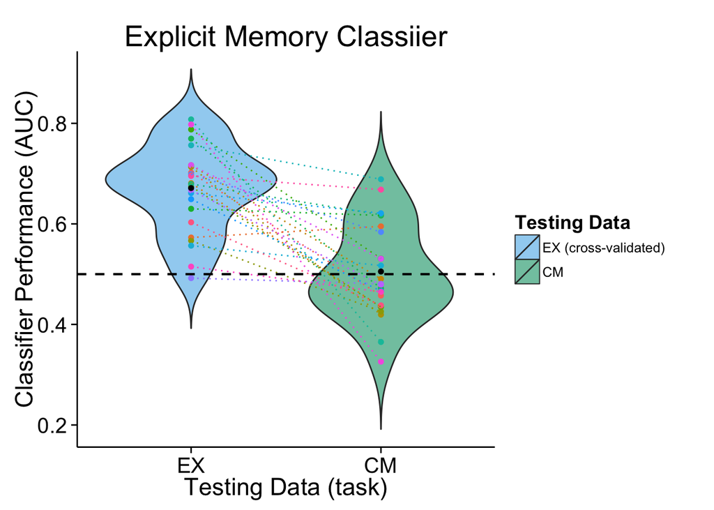

```r
plotMvpaViolin(subset(latetrs_mvpa_df,train_test %in% c('EX,4fold','EX>CM')))+
  labs(y="Classifier Performance (AUC)", x="Testing Data (task)", title="Explicit Memory Classiier")+
  scale_fill_manual(values=cbPalette,name="Testing Data",breaks=c("EX,4fold","EX>CM"),labels=c("EX (cross-validated)","CM"))+
  scale_x_discrete(breaks=c("EX,4fold","EX>CM"),labels=c("EX","CM"))
```

## Fig 4B. EX>EX & EX>CM TR by TR

First, I want to create a variable `trSec` that corresponds to the number of second post stimulus onset (rather than the tr number), so that we can put that on the x axis

```r
mvpa_dfS$trSec = as.numeric(mvpa_dfS$tr)*2-1
mvpa_dfS$trSec[mvpa_dfS$tr=='late'] = NA
```

Now that I have that, plot away

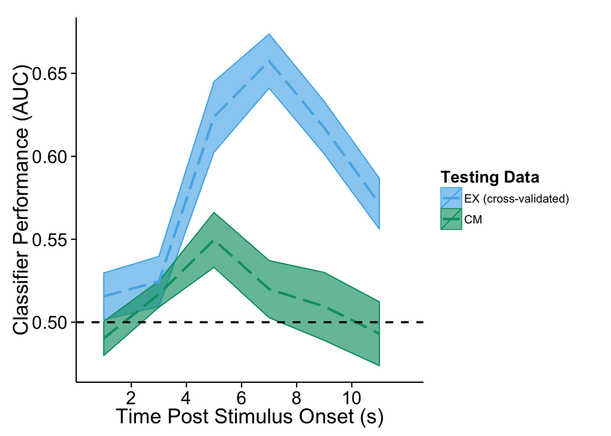

```r
plotMvpaTrRibbons(subset(mvpa_dfS, train_test %in% c("EX>CM","EX,4fold") & !is.na(trSec)))+
  scale_fill_manual(values=cbPalette,name="Testing Data",breaks=c("EX,4fold","EX>CM"),labels=c("EX (cross-validated)","CM"))+
  scale_color_manual(values=cbPalette,name="Testing Data",breaks=c("EX,4fold","EX>CM"),labels=c("EX (cross-validated)","CM"))+
  labs(x="Time Post Stimulus Onset (s)", y="Classifier Performance (AUC)")
```

## Fig 5A. Classifier Performance by Confidence

To explore these effects, we’re going to need to load new data that looks at trail by trial information, instead of binning across each classifier ###Load data

```r
mvpa_extocm_tr3_file = sprintf("%s/xvals2_runsrepotred_conds_hitVcr_trTe1_1_1_1_2_2_2_2_trW0__0__1__0__0__0_roiSEPT09_MVPA_MASK_resliced4mm.csv",dir)

mvpa_extocm_late_file = sprintf("%s/xvals2_runsrepotred_conds_hitVcr_trTe1_1_1_1_2_2_2_2_trWtr0___________0________0.33________0.34________0.33___________0_te0___________0________0.33________0.34________0.33___________0_roiSEPT09_MVPA_MASK_resliced4mm.csv",dir)


mvpa_ex_late_file = sprintf("%s/xvals_runsrepotred_conds_hitVcr_trTe1_2_3_4_0_0_0_0_trW0___________0________0.33________0.34________0.33___________0_roiSEPT09_MVPA_MASK_resliced4mm.csv",dir)

mvpa_extocm_tr3_df = read.csv(mvpa_extocm_tr3_file, header=T)
mvpa_extocm_late_df = read.csv(mvpa_extocm_late_file, header=T)
mvpa_ex_late_df = read.csv(mvpa_ex_late_file, header=T)
```

### Add labels to data and combine

```r
mvpa_extocm_tr3_df$name = 'extocm_tr3'
mvpa_extocm_late_df$name = 'extocm_late'
mvpa_ex_late_df$name = 'extoex_late'

confbyacc_df = rbind(mvpa_extocm_tr3_df,mvpa_extocm_late_df,mvpa_ex_late_df)
```

### Create percentile confidence bins of the data

```r
confbyacc_sorted_df = confbyacc_df[with(confbyacc_df, order(name, subs, -abs(actsVec-.5))),]
acc = numeric(0)
subj_num = integer(0)
mvpa_name = character(0)
bin_name = character(0)
bin_num=numeric(0)

bins =seq(1,.05,-.05)

names = unique(confbyacc_sorted_df$name)
x=0
for (iname in 1:length(names)){
  this_name = names[iname]
  for (jsub in unique(confbyacc_sorted_df$subs)){
    ntrials = length(with(confbyacc_sorted_df, confbyacc_sorted_df[subs==jsub & name==this_name, "subs"]))
    for (acc_bin in seq(1,20)){
      x=x+1
      included_trial_inds = 1:ceiling(ntrials * bins[acc_bin])
      mvpa_name[x]=this_name
      subj_num[x]=jsub
      bin_name[x] = sprintf('top %s%%',bins[acc_bin]*100)
      bin_num[x]=acc_bin
      acc[x] = with(subset(confbyacc_sorted_df,name==this_name & subs==jsub),mean(correctsVec[included_trial_inds]))
    }
  }
}

mvpa_accbyconf_df = data.frame(sub = subj_num,name = mvpa_name, acc=acc, bin_name=bin_name, bin_num=bin_num)

mvpa_accbyconf_df$bin_name = factor(mvpa_accbyconf_df$bin_name,
                                      levels=(mvpa_accbyconf_df$bin_name[1:20]))
```

### Fit a model and make a plot of accuracy by percentile confidence

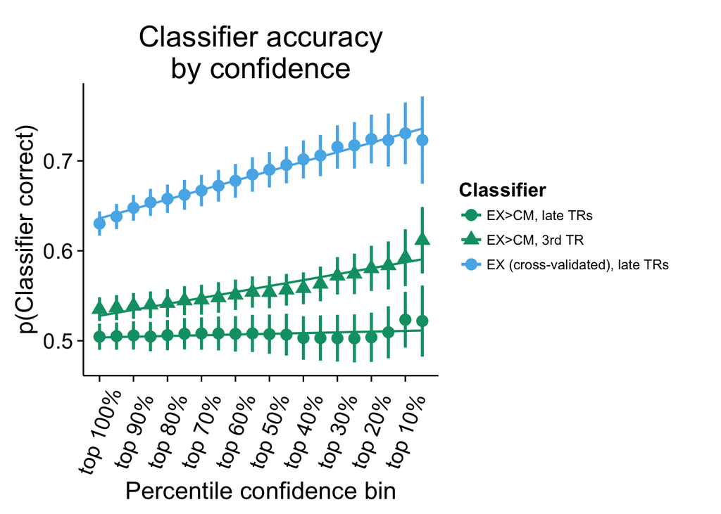

```r
confacc_ag<-ddply(mvpa_accbyconf_df,c("bin_num","name"),summarise,N=length(acc),mean_acc=mean(acc),sd_acc = sd(acc), sem_acc=sd_acc/sqrt(N), min_acc = mean_acc-sem_acc, max_acc = mean_acc+sem_acc)

model<- lm(acc~bin_num*name,data=mvpa_accbyconf_df)
grid <- with(mvpa_accbyconf_df, expand.grid(
  name = levels(name),
  bin_num = bin_num
))
grid$acc<-stats::predict(model,newdata=grid)

confacc_plt<-ggplot(mvpa_accbyconf_df,aes(x=bin_num,y=acc,group=name,color=name))+plotformat+labs(x='Percentile confidence bin',y=expression("p(Classifier correct)"),title="Classifier accuracy\nby confidence")+theme(axis.text.x  = element_text(angle=70, vjust=0.5))

confacc_plt+geom_pointrange(data=confacc_ag,aes(x=bin_num,y=mean_acc,ymin=min_acc,ymax=max_acc,shape=name),size=1)+  geom_line(data=grid,size=.75) + scale_x_continuous(labels=mvpa_accbyconf_df$bin_name[seq(1,20,2)],breaks=seq(1,20,2))+scale_color_manual(breaks=c("extocm_late","extocm_tr3","extoex_late"),labels=c("EX>CM, late TRs", "EX>CM, 3rd TR","EX (cross-validated), late TRs"),name='Classifier',values=cbPalette[c(2,2,1)])+scale_shape_manual(breaks=c("extocm_late","extocm_tr3","extoex_late"),labels=c("EX>CM, late TRs", "EX>CM, 3rd TR","EX (cross-validated), late TRs"),name='Classifier',values=c(16,17,16))
```

```r
confacc_ag
```

```
##    bin_num        name  N mean_acc  sd_acc sem_acc min_acc max_acc
## 1        1 extocm_late 24   0.5045 0.07149 0.01459  0.4899  0.5191
## 2        1  extocm_tr3 24   0.5352 0.06472 0.01321  0.5220  0.5484
## 3        1 extoex_late 24   0.6304 0.06580 0.01343  0.6170  0.6438
## 4        2 extocm_late 24   0.5052 0.07390 0.01508  0.4901  0.5203
## 5        2  extocm_tr3 24   0.5369 0.06808 0.01390  0.5230  0.5508
## 6        2 extoex_late 24   0.6382 0.06855 0.01399  0.6242  0.6522
## 7        3 extocm_late 24   0.5059 0.07677 0.01567  0.4903  0.5216
## 8        3  extocm_tr3 24   0.5388 0.07023 0.01434  0.5245  0.5531
## 9        3 extoex_late 24   0.6478 0.07019 0.01433  0.6335  0.6621
## 10       4 extocm_late 24   0.5047 0.07975 0.01628  0.4884  0.5210
## 11       4  extocm_tr3 24   0.5400 0.07297 0.01490  0.5251  0.5549
## 12       4 extoex_late 24   0.6539 0.07382 0.01507  0.6388  0.6689
## 13       5 extocm_late 24   0.5063 0.08253 0.01685  0.4894  0.5231
## 14       5  extocm_tr3 24   0.5419 0.07656 0.01563  0.5262  0.5575
```

[output cut: 46 more lines]

## Fig 5B. EX>CM TR3 Classifier Performance by CM d’

```r
excmtr3 = mvpa_df[mvpa_df$tr==3 & mvpa_df$train_test=="EX>CM",]
excmtr3$cm_d = behav_df$cm_d
excmtr3$ex_d = behav_df$ex_d
```

```r
#what about with ex d'?
with(excmtr3,cor.test(auc,ex_d))
```

```
##
##  Pearson's product-moment correlation
##
## data:  auc and ex_d
## t = 1.472, df = 22, p-value = 0.1552
## alternative hypothesis: true correlation is not equal to 0
## 95 percent confidence interval:
##  -0.1183  0.6271
## sample estimates:
##    cor
## 0.2994
```

**EX d’ is NOT significantly correlated with EX>CM AUC at tr 3 (4-6s post stimulus)**

```r
#are these correlated with cm d'
with(excmtr3,cor.test(auc,cm_d))
```

```
##
##  Pearson's product-moment correlation
##
## data:  auc and cm_d
## t = 2.41, df = 22, p-value = 0.02474
## alternative hypothesis: true correlation is not equal to 0
## 95 percent confidence interval:
##  0.06581 0.72651
## sample estimates:
##    cor
## 0.4571
```

**CM d’ is significantly correlated with EX>CM AUC at tr 3 (4-6s post stimulus)**

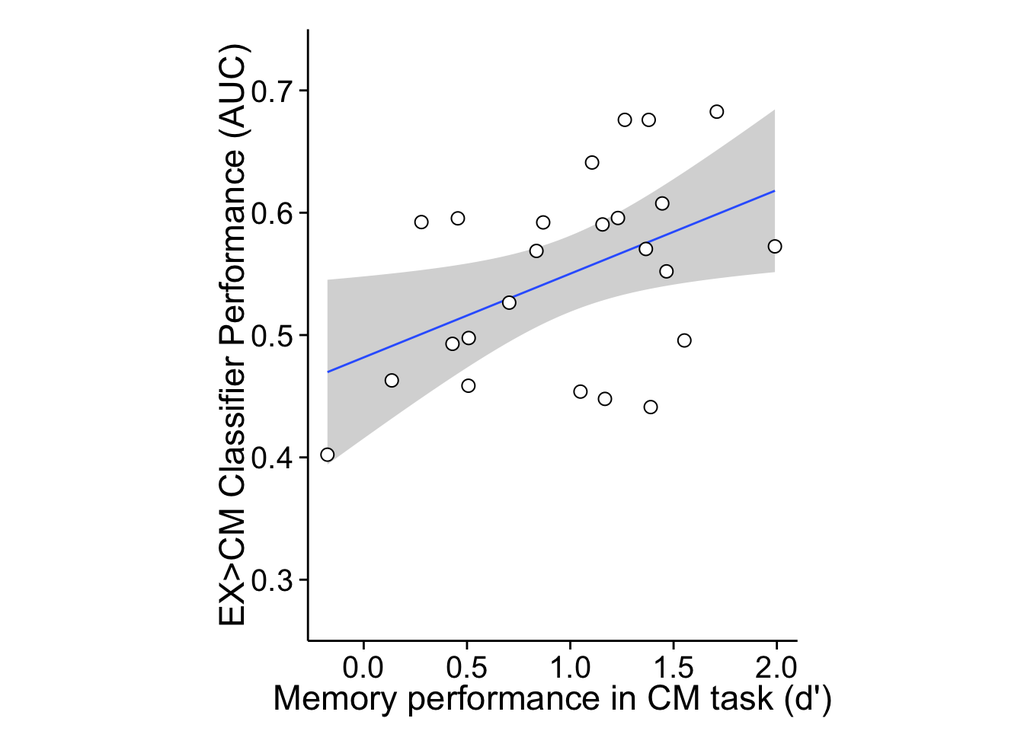

```r
#plot them
ggplot(excmtr3,aes(y=auc,x=cm_d))+geom_smooth(method="lm")+geom_point(size=3,fill='white',shape=21)+plotformat+labs(y="EX>CM Classifier Performance (AUC)",x="Memory performance in CM task (d')")+coord_fixed(ratio=2.37/.4,xlim=c(-.27,2.1),ylim=c(.25,.75))
```

## Fig 6. CM>CM and CM>EX Violins!

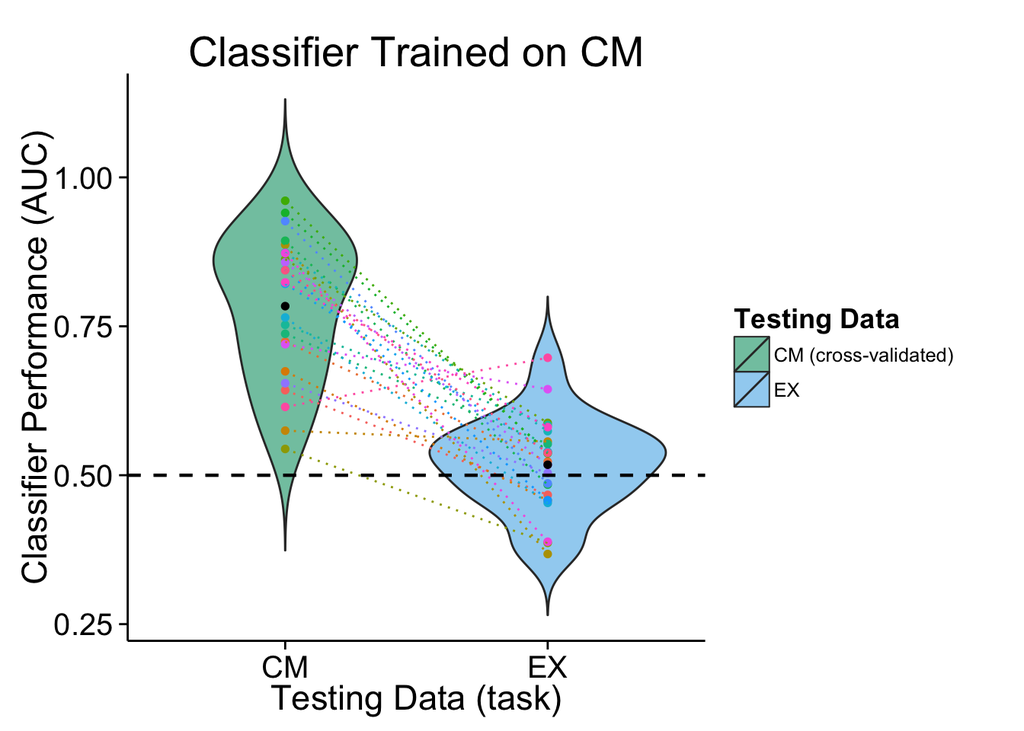

```r
plotMvpaViolin(subset(latetrs_mvpa_df,train_test %in% c('CM,4fold','CM>EX')))+
  labs(y="Classifier Performance (AUC)", x="Testing Data (task)", title="Classifier Trained on CM")+
  scale_fill_manual(values=cbPalette[c(2,1)],name="Testing Data",breaks=c("CM,4fold","CM>EX"),labels=c("CM (cross-validated)","EX"))+
  scale_x_discrete(breaks=c("CM,4fold","CM>EX"),labels=c("CM","EX"))
```

First, load the data from our special TR sweep results sheet.

```r
trsweeptrsweep_file = sprintf('%s/aucSummary__EXCMTrSweep.csv',dir)
trsweeptrsweep_df = read.csv(trsweeptrsweep_file,header=T)
trsweep_df=trsweeptrsweep_df
```

# ROIS

## ROI TR sweep: Train on tr 3, test on all trs

```r
trsweep_file = sprintf('%s/aucSummary__trsweep.csv',dir)
trsweep_df = read.csv(trsweep_file,header=T)
```

```r
trsweep_df$scramble = as.factor(trsweep_df$scramble)
trsweep_df$conds_traintest = with(trsweep_df,paste(condNames, which_traintest))
```

```
summary(trsweep_df)
```

```r
trsweep_df = fixTrInMvpaDf(trsweep_df)
```

```r
trsweep_dfS<-ddply(trsweep_df,.(condNames,name,conds_traintest,which_traintest,trW,trW_train,trW_test,scramble,lateTrs,trSec,roiName),summarise,N=length(auc),mean_auc=mean(auc,na.rm=T),sd_auc = sd(auc,na.rm=T), sem_auc=sd_auc/sqrt(N),min_auc=mean_auc-sem_auc,max_auc=mean_auc+sem_auc)
```

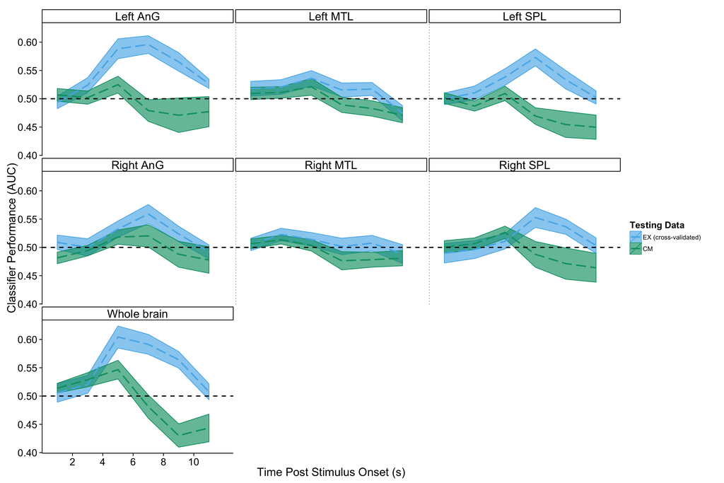

```r
trsweep_dfS$train_test[trsweep_dfS$condNames=='exHit;exCr']="EX, 2fold"
trsweep_dfS$train_test[trsweep_dfS$condNames=='hit;cr']='EX>CM'
trsweep_dfS$roiLabel = factor(trsweep_dfS$roiName, labels = c("Left AnG", "Left MTL", "Left SPL","Right AnG","Right MTL", "Right SPL", "Whole brain"))

plotMvpaTrRibbons(subset(trsweep_dfS,trW_train==3 & scramble == 0))+facet_wrap(~roiLabel)+
  scale_fill_manual(values=cbPalette,name="Testing Data",breaks=c("EX, 2fold","EX>CM"),labels=c("EX (cross-validated)","CM"))+
  scale_color_manual(values=cbPalette,name="Testing Data",breaks=c("EX, 2fold","EX>CM"),labels=c("EX (cross-validated)","CM"))+
  labs(x="Time Post Stimulus Onset (s)", y="Classifier Performance (AUC)")
```

*NOTE: EX>EX here is 2-fold cross-validated (as opposed to 4-fold)*

```r
#qplot(data=subset(trsweep_df,trW_train==3  & condNames=='hit;cr'),x=auc,group=interaction(roiName,trW_test,scramble),fill=as.factor(scramble),geom='bar',position='dodge',alpha=.5)+facet_wrap(~roiName+trW_test,ncol=6,scales='free')+plotformat
```

**Perhaps we should be increasing our power by using each iteration as an observation, rather than averaging and then comparing 24 observations**

```r
masks=levels(trsweep_df$roiName)
pvals=''
tvals=''
names=''
mean_auc=''
scram_mean_auc=''
k=0
for (j in 1:length(masks)){
  for (i in 1:6){
    k=k+1
    test = t.test(auc~scramble,data=subset(trsweep_df, trW_train==3  & condNames=='hit;cr' & trW_test==i & roiName==masks[j]),paired=T)
    pvals[k]= test$p.value
    mean_auc[k]= mean(with(trsweep_df, auc[scramble==0 & trW_train==3  & condNames=='hit;cr' & trW_test==i & roiName==masks[j]]))
        scram_mean_auc[k]= mean(with(trsweep_df, auc[scramble==1 & trW_train==3  & condNames=='hit;cr' & trW_test==i & roiName==masks[j]]))
    tvals[k]= test$statistic
    names[k]=sprintf('%s/%02d',masks[j],i)

  }
}
cbind(names,pvals,tvals, mean_auc, scram_mean_auc)
```

```
##       names                             pvals
##  [1,] "rleftAngMask_tbm112514.nii/01"   "0.731775109098433"
##  [2,] "rleftAngMask_tbm112514.nii/02"   "0.847651848569408"
##  [3,] "rleftAngMask_tbm112514.nii/03"   "0.0596869736582583"
##  [4,] "rleftAngMask_tbm112514.nii/04"   "0.289112328405143"
##  [5,] "rleftAngMask_tbm112514.nii/05"   "0.36587156328341"
##  [6,] "rleftAngMask_tbm112514.nii/06"   "0.378510207839805"
##  [7,] "rleftMtlMask_tbm112514.nii/01"   "0.716070531587443"
##  [8,] "rleftMtlMask_tbm112514.nii/02"   "0.517271784968238"
##  [9,] "rleftMtlMask_tbm112514.nii/03"   "0.0863239942713564"
## [10,] "rleftMtlMask_tbm112514.nii/04"   "0.414100738720086"
## [11,] "rleftMtlMask_tbm112514.nii/05"   "0.199367194553364"
## [12,] "rleftMtlMask_tbm112514.nii/06"   "0.054441567268908"
## [13,] "rleftSplMask_tbm112514.nii/01"   "0.86559564252388"
## [14,] "rleftSplMask_tbm112514.nii/02"   "0.205760953597749"
```

[output cut: 71 more lines]

## ROI TR by TR: Train and test on all trs

```r
trbytr_file = sprintf('%s/aucSummary_trbytr.csv',dir)
trbytr_df = read.csv(trbytr_file,header=T)
```

```r
trbytr_df$scramble = as.factor(trbytr_df$scramble)
trbytr_df$conds_traintest = with(trbytr_df,paste(condNames, which_traintest))
```

```
summary(trbytr_df)
```

```r
trbytr_df=fixTrInMvpaDf(trbytr_df)
```

```r
trbytr_dfS<-ddply(trbytr_df,.(condNames,name,conds_traintest,which_traintest,trW,trW_train,trW_test,trSec,scramble,lateTrs,roiName),summarise,N=length(auc),mean_auc=mean(auc,na.rm=T),sd_auc = sd(auc,na.rm=T), sem_auc=sd_auc/sqrt(N),min_auc=mean_auc-sem_auc,max_auc=mean_auc+sem_auc)
```

```
## geom_path: Each group consist of only one observation. Do you need to adjust the group aesthetic?
```

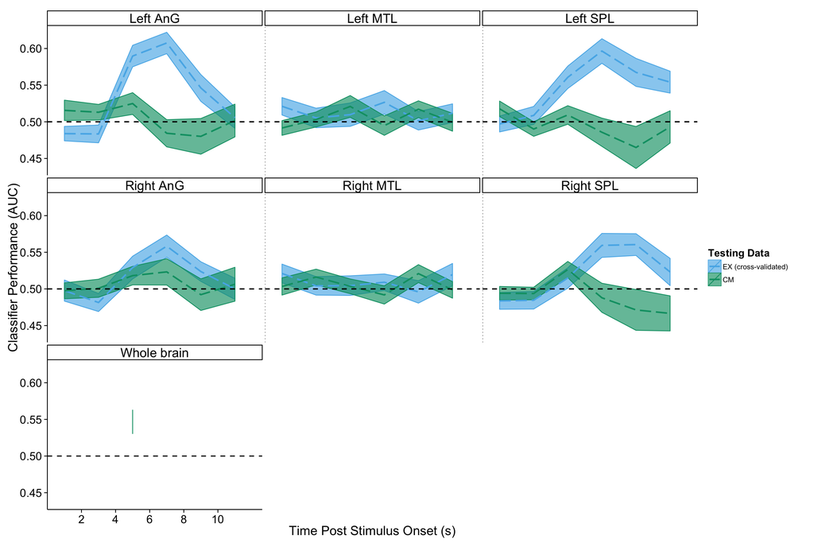

```r
trbytr_dfS$trSec[trbytr_dfS$tr=='late'] = NA
trbytr_dfS$train_test[trbytr_dfS$conds_traintest=='exHit;exCr 1;2;3;4;1;2;3;4']="EX, 4fold"
trbytr_dfS$train_test[trbytr_dfS$conds_traintest=='hit;cr 1;1;1;1;2;2;2;2']='EX>CM'
trbytr_dfS$roiLabel = factor(trbytr_dfS$roiName, labels = c("Left AnG", "Left MTL", "Left SPL","Right AnG","Right MTL", "Right SPL", "Whole brain"))

plotMvpaTrRibbons(subset(trbytr_dfS, scramble == 0))+facet_wrap(~roiLabel)+
  scale_fill_manual(values=cbPalette,name="Testing Data",breaks=c("EX, 4fold","EX>CM"),labels=c("EX (cross-validated)","CM"))+
  scale_color_manual(values=cbPalette,name="Testing Data",breaks=c("EX, 4fold","EX>CM"),labels=c("EX (cross-validated)","CM"))+
  labs(x="Time Post Stimulus Onset (s)", y="Classifier Performance (AUC)")
```

```r
#qplot(data=subset(trbytr_df,  condNames=='hit;cr'),x=auc,group=interaction(roiName,trW_test,scramble),fill=as.factor(scramble),geom='bar',position='dodge',alpha=.5)+facet_wrap(~roiName+trW_test,ncol=6,scales='free')+plotformat
```

**Perhaps we should be increasing our power by using each iteration as an observation, rather than averaging and then comparing 24 observations**

```r
masks=levels(trbytr_df$roiName)
pvals=''
tvals=''
names=''
k=0
for (j in 1:(length(masks)-1)){
  for (i in 1:6){
    k=k+1
    test = t.test(auc~scramble,data=subset(trbytr_df, condNames=='hit;cr' & trW_test==i & roiName==masks[j]),paired=T)
    pvals[k]= test$p.value
    tvals[k]= test$statistic
    names[k]=sprintf('%s/%02d',masks[j],i)

  }
}
cbind(names,pvals,tvals)
```

```
##       names                            pvals
##  [1,] "rleftAngMask_tbm112514.nii/01"  "0.170759145628365"
##  [2,] "rleftAngMask_tbm112514.nii/02"  "0.355658028763833"
##  [3,] "rleftAngMask_tbm112514.nii/03"  "0.0596869736582583"
##  [4,] "rleftAngMask_tbm112514.nii/04"  "0.463189787603006"
##  [5,] "rleftAngMask_tbm112514.nii/05"  "0.44110229281271"
##  [6,] "rleftAngMask_tbm112514.nii/06"  "0.847589715048873"
##  [7,] "rleftMtlMask_tbm112514.nii/01"  "0.728022621339698"
##  [8,] "rleftMtlMask_tbm112514.nii/02"  "0.838550206315889"
##  [9,] "rleftMtlMask_tbm112514.nii/03"  "0.0863239942713564"
## [10,] "rleftMtlMask_tbm112514.nii/04"  "0.977674717362868"
## [11,] "rleftMtlMask_tbm112514.nii/05"  "0.0962227392975647"
## [12,] "rleftMtlMask_tbm112514.nii/06"  "0.654228436658367"
## [13,] "rleftSplMask_tbm112514.nii/01"  "0.184901349898389"
## [14,] "rleftSplMask_tbm112514.nii/02"  "0.283385336257905"
```

[output cut: 59 more lines]

```r
masks=levels(trbytr_df$roiName)
pvals=''
tvals=''
names=''
k=0
for (j in 1:(length(masks)-1)){
  for (i in 1:6){
    k=k+1
    test = t.test(auc~scramble,data=subset(trbytr_df, condNames=='exHit;exCr' & trW_test==i & roiName==masks[j]),paired=T)
    pvals[k]= test$p.value
    tvals[k]= test$statistic
    names[k]=sprintf('%s/%02d',masks[j],i)

  }
}
cbind(names,pvals,tvals)
```

```
##       names                            pvals
##  [1,] "rleftAngMask_tbm112514.nii/01"  "0.0547662244938946"
##  [2,] "rleftAngMask_tbm112514.nii/02"  "0.0157151230545827"
##  [3,] "rleftAngMask_tbm112514.nii/03"  "3.05901537744776e-06"
##  [4,] "rleftAngMask_tbm112514.nii/04"  "4.93548550516581e-07"
##  [5,] "rleftAngMask_tbm112514.nii/05"  "0.0435566991834123"
##  [6,] "rleftAngMask_tbm112514.nii/06"  "0.643088035016053"
##  [7,] "rleftMtlMask_tbm112514.nii/01"  "0.136005288551719"
##  [8,] "rleftMtlMask_tbm112514.nii/02"  "0.968494349621642"
##  [9,] "rleftMtlMask_tbm112514.nii/03"  "0.450746313403777"
## [10,] "rleftMtlMask_tbm112514.nii/04"  "0.121994593176254"
## [11,] "rleftMtlMask_tbm112514.nii/05"  "0.991653909182622"
## [12,] "rleftMtlMask_tbm112514.nii/06"  "0.626248328815073"
## [13,] "rleftSplMask_tbm112514.nii/01"  "0.814043649052236"
## [14,] "rleftSplMask_tbm112514.nii/02"  "0.670090085701614"
```

[output cut: 59 more lines]

# Other useful stats

## How does EX>CM decoding compare to chance

```r
excmscram = read.csv(sprintf('%s/aucSummary_wb_excm_late_scram.csv',dir),header=T)
t.test(with(mvpa_df,auc[train_test=='EX>CM' & tr=='late']), with(excmscram,auc[scramble==1]),paired=T)
```

```
##
##  Paired t-test
##
## data:  with(mvpa_df, auc[train_test == "EX>CM" & tr == "late"]) and with(excmscram, auc[scramble == 1])
## t = 0.325, df = 23, p-value = 0.7481
## alternative hypothesis: true difference in means is not equal to 0
## 95 percent confidence interval:
##  -0.03560  0.04887
## sample estimates:
## mean of the differences
##                0.006636
```

## How does EX>EX decoding compare to chance

```r
exexscram = read.csv(sprintf('%s/aucSummary_wb_late_exex_scram.csv',dir),header=T)
t.test(with(mvpa_df,auc[train_test=='EX,4fold' & tr=='late']), with(exexscram,auc[scramble==1]),paired=T)
```

```
##
##  Paired t-test
##
## data:  with(mvpa_df, auc[train_test == "EX,4fold" & tr == "late"]) and with(exexscram, auc[scramble == 1])
## t = 8.966, df = 23, p-value = 5.744e-09
## alternative hypothesis: true difference in means is not equal to 0
## 95 percent confidence interval:
##  0.1348 0.2157
## sample estimates:
## mean of the differences
##                  0.1753
```

## How does CM>EX decoding compare to chance

```r
cmexscram = read.csv(sprintf('%s/aucSummary_cmtoex_late.csv',dir),header=T)
t.test(with(mvpa_df,auc[train_test=='CM>EX' & tr=='late']), with(cmexscram,auc[scramble==1]),paired=T)
```

```
##
##  Paired t-test
##
## data:  with(mvpa_df, auc[train_test == "CM>EX" & tr == "late"]) and with(cmexscram, auc[scramble == 1])
## t = 1.168, df = 23, p-value = 0.2549
## alternative hypothesis: true difference in means is not equal to 0
## 95 percent confidence interval:
##  -0.01504  0.05402
## sample estimates:
## mean of the differences
##                 0.01949
```

## How does CM>CM decoding compare to chance

```r
cmcmscram= read.csv(sprintf('%s/aucSummary_cmtocm_late_wb.csv',dir),header=T)
t.test(with(mvpa_df,auc[train_test=='CM,4fold' & tr=='late']), with(cmcmscram,auc[scramble==1]),paired=T)
```

```
##
##  Paired t-test
##
## data:  with(mvpa_df, auc[train_test == "CM,4fold" & tr == "late"]) and with(cmcmscram, auc[scramble == 1])
## t = 12.75, df = 23, p-value = 6.536e-12
## alternative hypothesis: true difference in means is not equal to 0
## 95 percent confidence interval:
##  0.2486 0.3449
## sample estimates:
## mean of the differences
##                  0.2968
```

## How do CM>CM and EX>EX decoding compare?

```r
t.test(auc~train_test,data=subset(latetrs_mvpa_df, train_test %in% c('EX,4fold','CM,4fold') & tr=='late'),paired=T)
```

```
##
##  Paired t-test
##
## data:  auc by train_test
## t = -4.423, df = 23, p-value = 0.0001959
## alternative hypothesis: true difference in means is not equal to 0
## 95 percent confidence interval:
##  -0.16524 -0.05994
## sample estimates:
## mean of the differences
##                 -0.1126
```

## How does EX>CM at TR3 compare to chance?

```r
excmtr3S= read.csv(sprintf('%s/aucSummary_wb_tr3_excm_scram_unscram.csv',dir),header=T)
t.test(auc~scramble,data=excmtr3S,paired=T)
```

```
##
##  Paired t-test
##
## data:  auc by scramble
## t = 3.348, df = 23, p-value = 0.002787
## alternative hypothesis: true difference in means is not equal to 0
## 95 percent confidence interval:
##  0.02036 0.08619
## sample estimates:
## mean of the differences
##                 0.05328
```

## What about other Tr by tr analyses?

```r
excmtrs_scram= read.csv(sprintf('%s/aucSummary_wb_trbytr_excm_scrambled.csv',dir),header=T)
exextrs_scram= read.csv(sprintf('%s/aucSummary_wb_trbytr_exex_scrambled.csv',dir),header=T)

exextrs_scram=fixTrInMvpaDf(exextrs_scram)
t.test(with(mvpa_df, auc[tr==1 & train_test=='EX,4fold']),with(exextrs_scram, auc[trW_test==1]),paired=T)
```

```
##
##  Paired t-test
##
## data:  with(mvpa_df, auc[tr == 1 & train_test == "EX,4fold"]) and with(exextrs_scram, auc[trW_test == 1])
## t = 0.6427, df = 23, p-value = 0.5268
## alternative hypothesis: true difference in means is not equal to 0
## 95 percent confidence interval:
##  -0.02013  0.03827
## sample estimates:
## mean of the differences
##                0.009072
```

```r
t.test(with(mvpa_df, auc[tr==2 & train_test=='EX,4fold']),with(exextrs_scram, auc[trW_test==2]),paired=T)
```

```
##
##  Paired t-test
##
## data:  with(mvpa_df, auc[tr == 2 & train_test == "EX,4fold"]) and with(exextrs_scram, auc[trW_test == 2])
## t = 1.572, df = 23, p-value = 0.1295
## alternative hypothesis: true difference in means is not equal to 0
## 95 percent confidence interval:
##  -0.008342  0.061200
## sample estimates:
## mean of the differences
##                 0.02643
```

```r
t.test(with(mvpa_df, auc[tr==3 & train_test=='EX,4fold']),with(exextrs_scram, auc[trW_test==3]),paired=T)
```

```
##
##  Paired t-test
##
## data:  with(mvpa_df, auc[tr == 3 & train_test == "EX,4fold"]) and with(exextrs_scram, auc[trW_test == 3])
## t = 6.046, df = 23, p-value = 3.636e-06
## alternative hypothesis: true difference in means is not equal to 0
## 95 percent confidence interval:
##  0.08818 0.17992
## sample estimates:
## mean of the differences
##                   0.134
```

```r
t.test(with(mvpa_df, auc[tr==4 & train_test=='EX,4fold']),with(exextrs_scram, auc[trW_test==4]),paired=T)
```

```
##
##  Paired t-test
##
## data:  with(mvpa_df, auc[tr == 4 & train_test == "EX,4fold"]) and with(exextrs_scram, auc[trW_test == 4])
## t = 9.889, df = 23, p-value = 9.435e-10
## alternative hypothesis: true difference in means is not equal to 0
## 95 percent confidence interval:
##  0.1285 0.1965
## sample estimates:
## mean of the differences
##                  0.1625
```

```r
t.test(with(mvpa_df, auc[tr==5 & train_test=='EX,4fold']),with(exextrs_scram, auc[trW_test==5]),paired=T)
```

```
##
##  Paired t-test
##
## data:  with(mvpa_df, auc[tr == 5 & train_test == "EX,4fold"]) and with(exextrs_scram, auc[trW_test == 5])
## t = 7.194, df = 23, p-value = 2.523e-07
## alternative hypothesis: true difference in means is not equal to 0
## 95 percent confidence interval:
##  0.08366 0.15119
## sample estimates:
## mean of the differences
##                  0.1174
```

```r
t.test(with(mvpa_df, auc[tr==6 & train_test=='EX,4fold']),with(exextrs_scram, auc[trW_test==6]),paired=T)
```

```
##
##  Paired t-test
##
## data:  with(mvpa_df, auc[tr == 6 & train_test == "EX,4fold"]) and with(exextrs_scram, auc[trW_test == 6])
## t = 4.85, df = 23, p-value = 6.764e-05
## alternative hypothesis: true difference in means is not equal to 0
## 95 percent confidence interval:
##  0.04168 0.10367
## sample estimates:
## mean of the differences
##                 0.07267
```

```r
excmtrs_scram=fixTrInMvpaDf(excmtrs_scram)
t.test(with(mvpa_df, auc[tr==1 & train_test=='EX>CM']),with(excmtrs_scram, auc[trW_test==1]),paired=T)
```

```
##
##  Paired t-test
##
## data:  with(mvpa_df, auc[tr == 1 & train_test == "EX>CM"]) and with(excmtrs_scram, auc[trW_test == 1])
## t = -1.196, df = 23, p-value = 0.2441
## alternative hypothesis: true difference in means is not equal to 0
## 95 percent confidence interval:
##  -0.036236  0.009693
## sample estimates:
## mean of the differences
##                -0.01327
```

```r
t.test(with(mvpa_df, auc[tr==2 & train_test=='EX>CM']),with(excmtrs_scram, auc[trW_test==2]),paired=T)
```

```
##
##  Paired t-test
##
## data:  with(mvpa_df, auc[tr == 2 & train_test == "EX>CM"]) and with(excmtrs_scram, auc[trW_test == 2])
## t = 1.859, df = 23, p-value = 0.07593
## alternative hypothesis: true difference in means is not equal to 0
## 95 percent confidence interval:
##  -0.001965  0.036729
## sample estimates:
## mean of the differences
##                 0.01738
```

```r
t.test(with(mvpa_df, auc[tr==3 & train_test=='EX>CM']),with(excmtrs_scram, auc[trW_test==3]),paired=T)
```

```
##
##  Paired t-test
##
## data:  with(mvpa_df, auc[tr == 3 & train_test == "EX>CM"]) and with(excmtrs_scram, auc[trW_test == 3])
## t = 3.348, df = 23, p-value = 0.002787
## alternative hypothesis: true difference in means is not equal to 0
## 95 percent confidence interval:
##  0.02036 0.08619
## sample estimates:
## mean of the differences
##                 0.05328
```

```r
t.test(with(mvpa_df, auc[tr==4 & train_test=='EX>CM']),with(excmtrs_scram, auc[trW_test==4]),paired=T)
```

```
##
##  Paired t-test
##
## data:  with(mvpa_df, auc[tr == 4 & train_test == "EX>CM"]) and with(excmtrs_scram, auc[trW_test == 4])
## t = 0.6668, df = 23, p-value = 0.5115
## alternative hypothesis: true difference in means is not equal to 0
## 95 percent confidence interval:
##  -0.02640  0.05151
## sample estimates:
## mean of the differences
##                 0.01256
```

```r
t.test(with(mvpa_df, auc[tr==5 & train_test=='EX>CM']),with(excmtrs_scram, auc[trW_test==5]),paired=T)
```

```
##
##  Paired t-test
##
## data:  with(mvpa_df, auc[tr == 5 & train_test == "EX>CM"]) and with(excmtrs_scram, auc[trW_test == 5])
## t = 0.5094, df = 23, p-value = 0.6153
## alternative hypothesis: true difference in means is not equal to 0
## 95 percent confidence interval:
##  -0.03206  0.05301
## sample estimates:
## mean of the differences
##                 0.01047
```

```r
t.test(with(mvpa_df, auc[tr==6 & train_test=='EX>CM']),with(excmtrs_scram, auc[trW_test==6]),paired=T)
```

```
##
##  Paired t-test
##
## data:  with(mvpa_df, auc[tr == 6 & train_test == "EX>CM"]) and with(excmtrs_scram, auc[trW_test == 6])
## t = -0.4118, df = 23, p-value = 0.6843
## alternative hypothesis: true difference in means is not equal to 0
## 95 percent confidence interval:
##  -0.04539  0.03032
## sample estimates:
## mean of the differences
##               -0.007536
```